# Mining and Local Corruption in Africa

Carl Henrik Knutsen, Andreas Kotsadam, Eivind Hammersmark Olsen, Tore Wig

Replication Project by Lauren Gilbert

## Introduction

Why are countries with more natural resources less developed and less well-governed than countries with fewer resources? It is clear from a glance at the globe that this is true (on average); resource-rich countries like the Democratic Republic of Congo are some of the poorest countries on the planet, while resource-poor countries like Luxembourg are much wealthier. Sachs 1995 famously demonstrates that countries with high ratios of natural resource exports also experience lower growth rates. Later studies have focused on a particular link between natural resource wealth and corruption (e.g. Auty 2001).

Knutson et al. test to see if this link is casual or merely correlation. They note that traditional cross-country analysis may not identify causation (instead picking up the particularities of individual countries).

Instead, they focus on a micro-level study that allows for more precise identification of cause and effect. Specifically, they utilize a difference-in-difference design to determine if active mineral extraction has a causal impact on local corruption. They identify a local “resource curse”: that is, the opening of a mine causes the local corruption levels to increase.

## Replication

The authors use a geotagged database of past and current large-scale industrial mines, the Raw Materials Database (RMD) from SNL Metals and Mining. This database includes 496 mines, operating across Africa from 1984-2003. Smaller, informal, and artisanal mines are not included in the dataset.

This is linked with several measures of corruption from Afrobarometer. Afrobarometer survey data encompasses 30 countries over 10 years - allowing the authors to match respondents to distance to mine.

Of course, survey corruption data is inherently imprecise; to attempt to correct for variations between measures, the authors use data on both local perception of corruption and respondents’ reports of actually having paid bribes.

The authors use a difference-in-difference design in order to determine causality. They code three groups: residents (surveyed by Afrobarometer) within a cutoff region of an active mine, residents (surveyed by Afrobarometer) near a future mining site, and residents (surveyed by Afrobarometer) who do not live near a mine. They use a regression of the form:

$$Y_{ivt} = \beta_{active} * active + \beta_{inactive} * inactive + \alpha_c + g_t + \lambda X_i + \epsilon_{ivt}$$

… where Y is the measure of corruption, i the individual, v the cluster, t the year, $\alpha_c$ country fixed effects, $g_t$ year fixed effects, and $\lambda X_i$ a vector of individual controls (including age, education and gender).

The authors employ four possible measures of $Y$, or local corruption level:

1. “Police bribe” is a categorical variable that records if respondents have paid a bribe for “avoiding problems with the police” in the last year. The possible responses are “never” (0), “once or twice” (1), “a few times” (2), and “often” (3).
2. “Permit bribe” is a categorical variable that records if respondents have paid a bribe for “a document or permit”. The possible responses are the same as for “police bribe”, and range from “never” (0) to “often” (3)
3. “Local corruption” reports the respondent’s opinion on how many local government councilors are corrupt – respondents can choose between “none” (0), “some of them” (1), “most of them” (2) or “all of them” (3).
4. “Police corruption” reports the respondent’s opinion of how many local police are corrupt, again on a 0-3 scale.

The regressions will determine $\beta_{inactive}$, the effect that a future mine has on corruption levels, and $\beta_{active}$, the effect that an active mine site has on corruption levels. From these, the authors calculate $\beta_{active}$ - $\beta_{inactive}$, the *change* in corruption when a mine opens.

The results for these regressions are below:

|  | (1) Police Bribes | (2) Permit Bribes | (3) Local Corruption | (4) Police Corruption |
| --- | --- | --- | --- | --- |
| $\beta_{active}$ | $0.023952$ ** | $0.0148954$ | $0.0258622$* | $0.0688438$ *** |
| $\beta_{inactive}$ | $-0.0497309$ *** | $-0.0238543$ | $-0.0888403$ | $0.0627532$ |
| $\beta_{active} - \beta_{inactive}$ | $0.0736829$ | $0.0387497$ | $0.1147025$ | $0.0060907$ |
| F test ($\beta_{active} - \beta_{inactive} = 0$) | 28.31 | 2.950 | 4.813 | 0.0332 |
| p value | 0.000000106 *** | 0.0859 | 0.0283 * | 0.855 |
| Mean dependent variable | 0.222633 | 0.228594 | 1.3054277 | 1.608972 |
| R squared | 0.0770064 | 0.0640298 | 0.095547 | 0.1005886 |
| Observations | 92762 | 92863 | 63481 | 83860 |

Items with *** are significant at the 0.001 level, ** at the 0.01 level and * at the 0.05 level. (F test and p values were found in Stata.)

## Further Work

In the author’s model, a mining area is coded dichotomously with a specific cutoff distance. However, analysis based on distance to the source of corruption (the mine) may be informative. We would expect to see a drop-off in corruption as distance from the corruption “source” increases. This drop-off should not exist for our placebo, future mining locations, as there is no “corruption source”.

Therefore, we study how corruption changes with distance for both locations with current and future mines. This is explicitly not a difference-in-difference design, because it is not evaluated over time, but is similar in nature. We will not be able to determine causality - again, it does not evaluate over time - but it will serve to support (or undermine) the previously-drawn conclusions of the original paper.

### Analysis

We begin by simply plotting how the corruption level varies with distance. We will do two regression lines: one for active mines and one for inactive mines, of the form:

$$Y = \beta_{0,active} + \beta_{active} * \mathrm{distance\ (km)}$$
$$Y = \beta_{0,inactive} + \beta_{inactive} * \mathrm{distance\ (km)}$$
We plot the resulting regressions. Active mining areas data (regression and survey respondent’s ) are plotted in teal, while inactive mining areas (regression and data) are plotted in coral. Coefficients for the regressions are reported in more detail after the graphs.

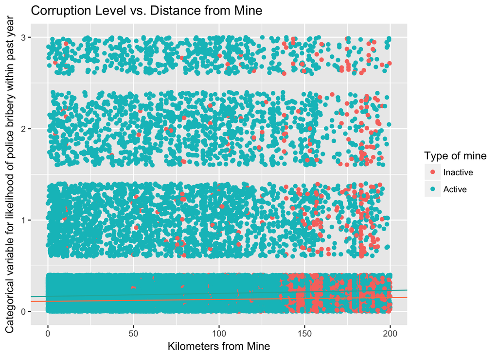

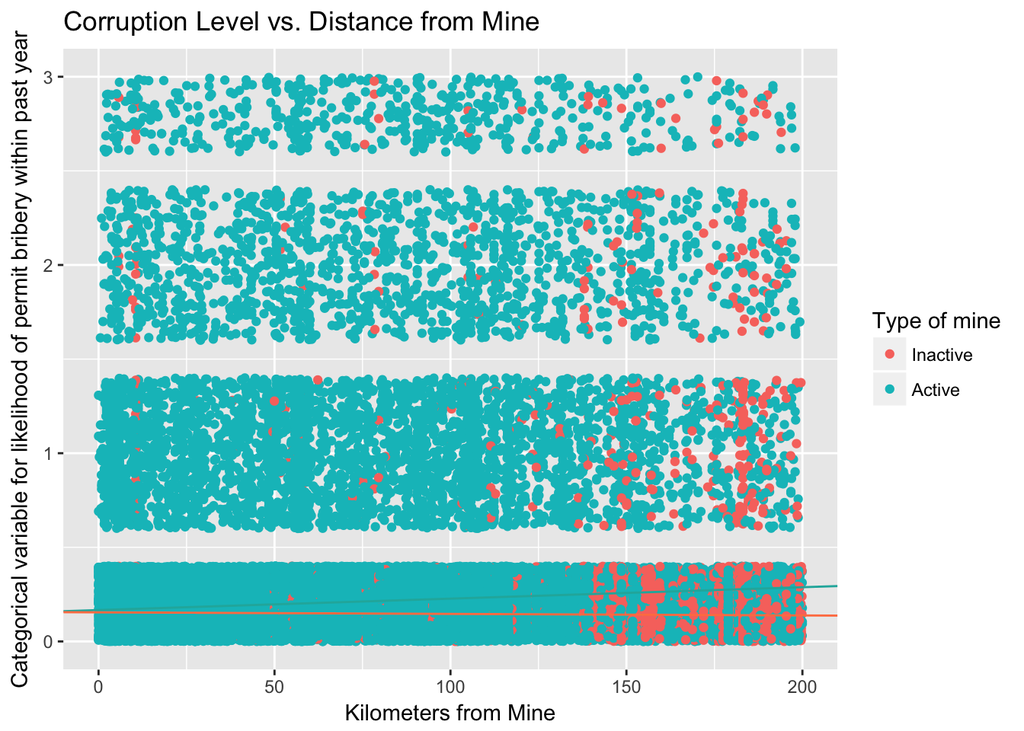

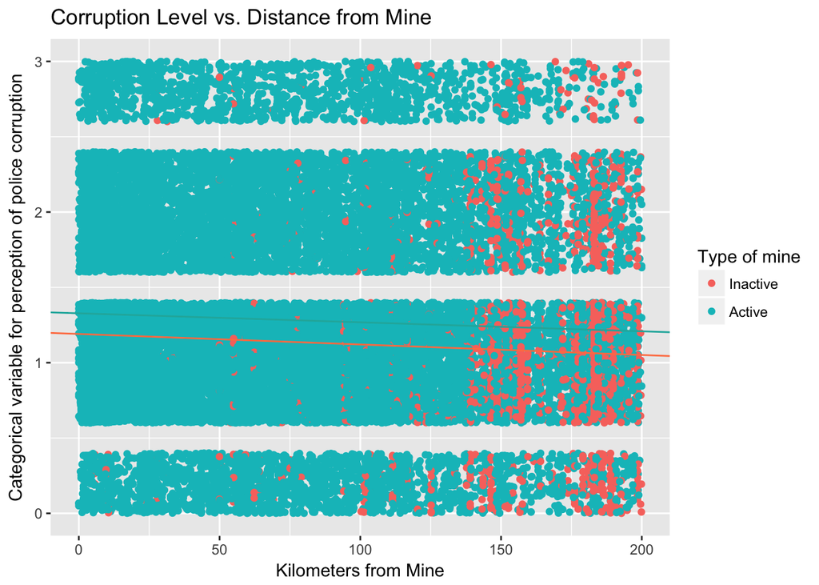

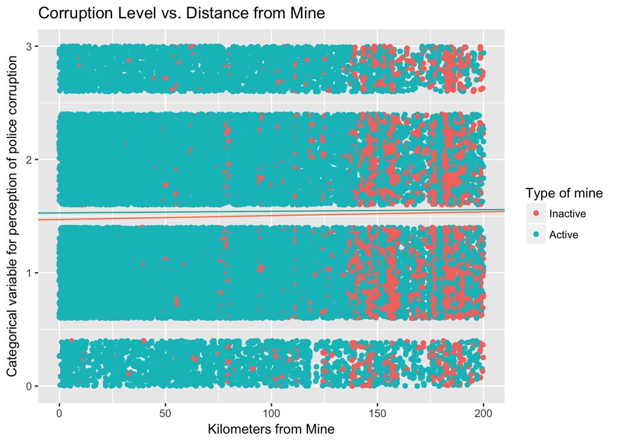

Without controls:

|  | (1) Police Bribes | (2) Permit Bribes | (3) Local Corruption | (4) Police Corruption |
| --- | --- | --- | --- | --- |
| $\beta_{0,active}$ | $0.1655384$ *** | $0.1666873$ *** | $1.3284591$ *** | $1.5286184$ *** |
| $\beta_{active}$ | $3.272395\times 10^{-4}$ ** | $6.0802449\times 10^{-4}$ *** | $-6.0062982\times 10^{-4}$ ** | $1.4486863\times 10^{-4}$ |
| $\beta_{0,inactive}$ | $0.1116064$ *** | $0.155268$ *** | $1.1909817$ *** | $1.4706102$ *** |
| $\beta_{inactive}$ | $2.0554295\times 10^{-4}$ | $-8.5866828\times 10^{-5}$ | $-6.9955738\times 10^{-4}$ | $3.385138\times 10^{-4}$ |

Clearly areas with active mines have higher levels of corruption than areas with future mines, but the above does not take into account covariates or other reasons inactive mining areas may differ from areas with active mines.

For a more complete view of how corruption levels change with active mining, we must include covariates, year fixed-effects, and country fixed-effects in our analysis.

We use regressions of the form:

$$Y_{ivt,active} = \beta_{0,active} + \beta_{active} * \mathrm{distance} + \alpha_c + g_t + \lambda X_i + \epsilon_{ivt}$$
$$Y_{ivt,inactive} = \beta_{0,inactive} + \beta_{inactive} * \mathrm{distance} + \alpha_c + g_t + \lambda X_i + \epsilon_{ivt}$$
… where Y is the measure of corruption, i the individual, v the cluster, t the year, $\beta_0$ the intercept (and thus baseline level of corruption 0 km from the mine), $\beta_{active}$ the coefficient for how corruption changes with distance from an active mine, $\beta_{inactive}$ the coefficient for how corruption changes with distance from an inactive mine, $\alpha_c$ country fixed effects, $g_t$ year fixed effects, and $\lambda X_i$ a vector of individual controls (including age, education and gender).

Since corruption is not a well-defined concept, we will continue follow the original paper in reporting results based on multiple (survey-based) measures of corruption ($Y_{ivt}$). The corruption variables are the same as above - prevalence of police bribes, prevalence of bribes for permits, perception of corruption among local officials, and perception of corruption among local police.

The coefficients for those regressions are:

|  | (1) Police Bribes | (2) Permit Bribes | (3) Local Corruption | (4) Police Corruption |
| --- | --- | --- | --- | --- |
| $\beta_{0,active}$ (baseline corruption, with controls) | $0.0555716$ | $0.0172312$ | $1.1148677$ *** | $0.5467655$ *** |
| $\beta_{active}$ (with controls) | $-1.00979\times 10^{-4}$ | $-1.3236392\times 10^{-5}$ | $-2.981192\times 10^{-4}$ | $-6.9693935\times 10^{-4}$ *** |
| $\beta_{0, inactive}$ (baseline corruption, with controls) | $-0.0297168$ | $0.0511679$ | $1.1324603$ *** | $1.5539186$ *** |
| $\beta_{inactive}$ (with controls) | $2.8418249\times 10^{-4}$ | $-2.6586903\times 10^{-4}$ | $3.3632197\times 10^{-6}$ | $-2.4909241\times 10^{-4}$ *** |

Items with *** are significant at the 0.001 level, ** at the 0.01 level and * at the 0.05 level.

The change in corruption with distance from an active mine ($\beta_{active}$) is signed as expected (a decrease with distance), but the coefficient is *extremely* small. Corruption is essentially constant with distance. Furthermore, only under one specification of corruption is the coefficient significant. (Though as we will see later in this analysis, it is extremely likely that the coefficient is indeed less than zero.)

The results for $\beta_{inactive}$ are less easy to interpret. Some measures of corruption increase with distance to a future mine, while some decrease. It is unclear if corruption increases or decreases with distance to a future mine site.

We have three hypotheses to test against these results:

1. $\beta_{active}$ is negative – that is, if mining is the cause of increased local corruption, corruption should decrease with distance. We will test this with a one-sample t test.
2. $\beta_{inactive}$ is 0 – we expect no relationship between corruption and distance to a future mine. We will test this with a one-sample t-test.
3. $\beta_{0,active} - \beta_{0,inactive} > 0$ – the baseline corruption, 0 km from a mining site, will be higher when there is an active mine rather than a future mine. We will test this with a two-sample t-test.

This results in the following p values:

Without controls:

|  | Police Bribes | Permit Bribes | Local Corruption | Police Corruption |
| --- | --- | --- | --- | --- |
| $\beta_{active}$ $< 0$ | 1 | 1 | 0*** | 1 |
| $\beta_{inactive}$ $= 0$ | $1$ | $8.8207673\times 10^{-125}$*** | $0$*** | $1$ |

We also evaluate $\beta_{active} - \beta_{inactive}$ and its significance:

|  | Police Bribes | Permit Bribes | Local Corruption | Police Corruption |
| --- | --- | --- | --- | --- |
| $\beta_{0,active} - \beta_{0,inactive}$ | $0.053932$ | $0.0114193$ | $0.1374774$ | $0.0580082$ |
| p value for ($\beta_{0,active} = \beta_{0,inactive} > 0$) | 0.4999993 | $0.4999987$ | 0.4999903 | 0.4999982 |

With controls:

|  | Police Bribes | Permit Bribes | Local Corruption | Police Corruption |
| --- | --- | --- | --- | --- |
| $\beta_{active}$ $< 0$ | 0*** | $8.6235895\times 10^{-182}$ *** | 0 *** | 0 *** |
| $\beta_{inactive}$ $= 0$ | 1 | 0 *** | 0.6666122 | 0 *** |

$\beta_{active}$ is statistically different than zero in all cases. However, as it is so small, it is not substantively different from zero.

Lastly, as different corruption measures lead to wildly varying values of statistical significance for $\beta_{inactive}$, we can draw no conclusions here.

We again evaluate $\beta_{active} - \beta_{inactive}$ and its significance (this time with controls):

[output not shown]

Thus, the result that active mining areas have more corruption than inactive areas is *not* statistically significant. We cannot reject the null hypothesis that $\beta_{active} = \beta_{inactive}$. The corruption levels at the site of an active mine and at the site of a future mine may not differ at all.

## Conclusions

We see little of the results that would be expected if mines were a localized source of corruption. While corruption does drop off as one moves away from the mine, the effect is miniscule - for at least 200 km around a mine, the local corruption level is virtually the same. There could, of course, be reasons for this - corruption could be less localized than the authors posit, our survey-based measures simply can’t pick up changes - but as is, mines do not seem to have a localized effect on corruption.

Furthermore, the original paper’s secondary result that future mine locations have less corruption than active mine locations does not hold up in this analysis. We cannot reject the null hypothesis that the corruption level at 0 km from an active mine and the corruption level 0 km from future mining locations are the same.

Not rejecting the null hypothesis does not make the null hypothesis definitively true. We simply cannot eliminate the possibility that there may be no difference in corruption levels in future and current mining locations.

Still, taken together, these results cast some doubt on the paper’s findings that mines cause local corruption to increase. Our results are consistent with a new mine opening resulting in zero change in corruption level. We certainly do not see a strong signal that mines cause local corruption.

## References

Auty, R. “The Political Economy of Resource-Driven Growth”. *European Economic Review*, 2001, vol. 45, issue 4-6, 839-846.

Knutsen, C. H., Kotsadam, A., Olsen, E. H., Wig T. “Mining and Local Corruption in Africa”. *American Journal of Political Science*, 2017, vol. 61, pg. 320-334. https://onlinelibrary.wiley.com/doi/full/10.1111/ajps.12268.

Sachs, J., and Warner, A. “Natural Resource Abundance and Economic Growth”. *NBER Working Paper Series*. December 1995. https://www.nber.org/papers/w5398.pdf.